# Data Camp / ARIMA Modeling with R - Chapter 2

Initialize and load the data

```r
library(astsa)
library(xts)
```

Chapter 2 of [Data Camp - ARIMA Modeling with R](https://www.datacamp.com/courses/arima-modeling-with-r)

## AR and MA Models

### How to identify the model?

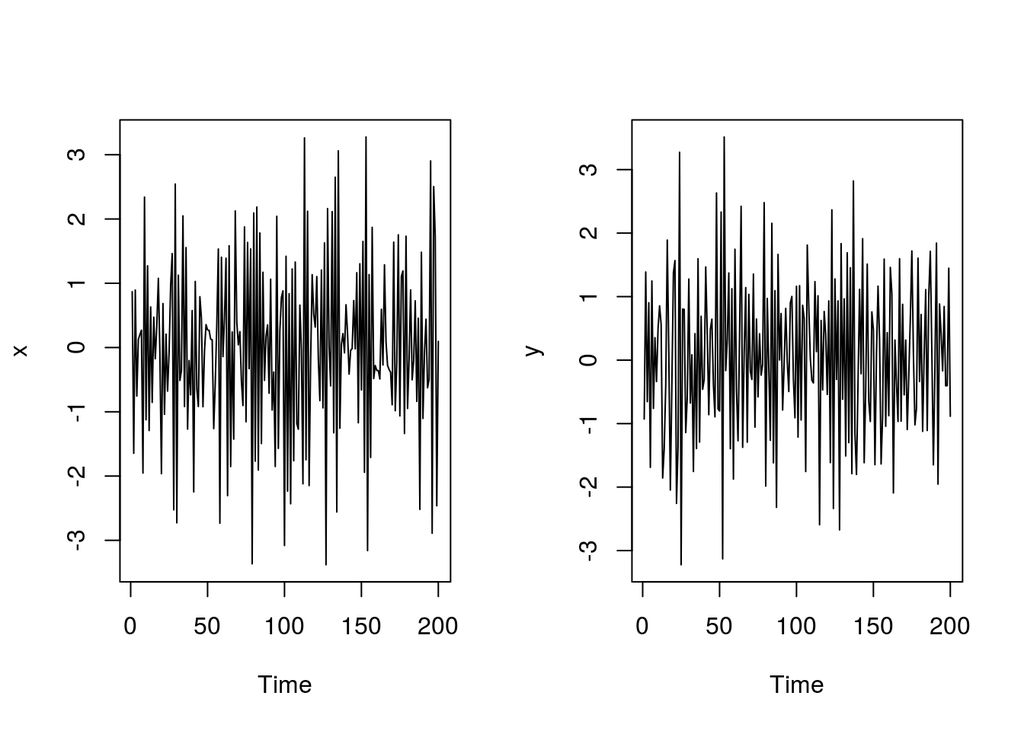

```r
x = arima.sim(model=list(order=c(1, 0, 0), ar=(-0.7)), n=200)
y = arima.sim(model=list(order=c(0, 0, 1), ma=(-0.7)), n=200)

par(mfrow=c(1,2))
plot(x)
plot(y)
```

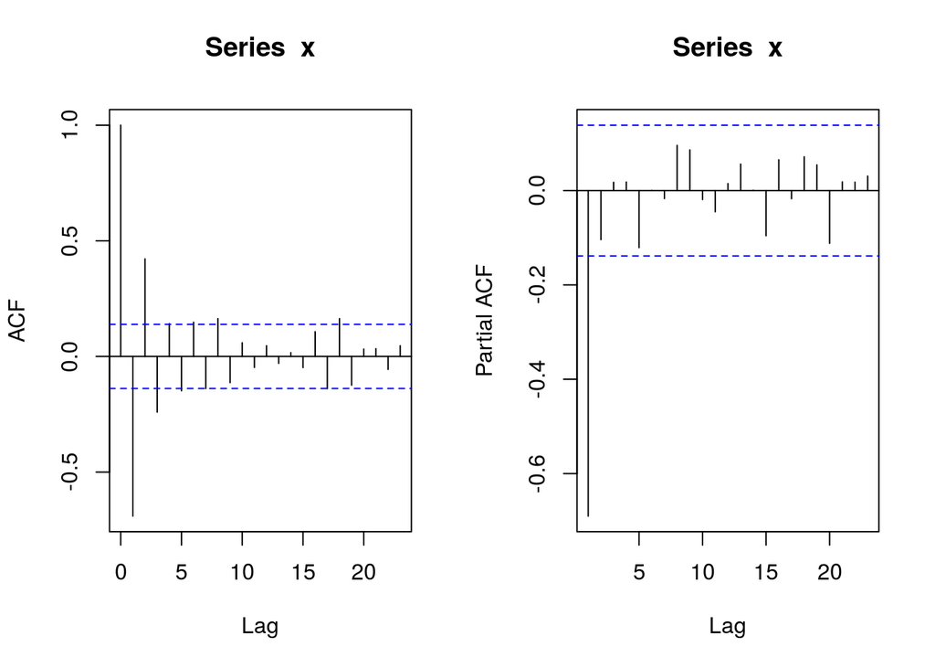

```r
acf(x)
pacf(x)
```

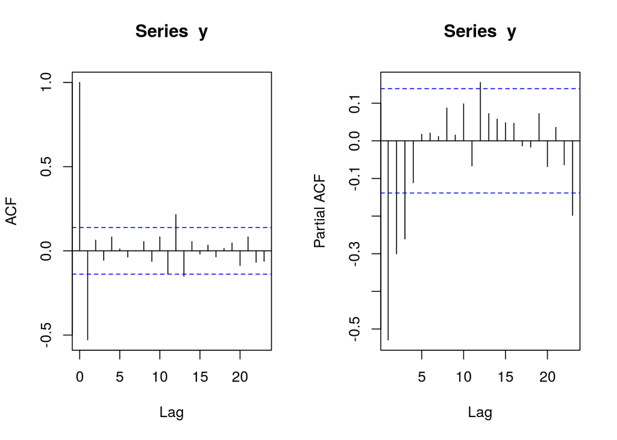

```r
acf(y)
pacf(y)
```

Above are 2 models, AR and MA with similar patters. Looking it’s not clear which is which. Should use the `acf()` and `pacf()` functions. More conveniently, since they are often printed together, use the `acf2()` which prints, wait for it, … both.

| AR(p) | MA(q) | ARMA(p,q) |  |
| --- | --- | --- | --- |
| ACF | Tails off | Cuts off lag q | Tails off |
| PACF | Cuts off lag p | Tails of | Tails off |

### Estimating

Similar to Regression using least squares. Unfortunately this is more difficult than with Regression and not as clear. Estimates are obtained numerically using ideas of Guass and Newton.

The **astsa** package has a front end to the `arima()` function `sarima()`, which can be used. It makes the interface a bit simpler and does some nice after the fact optimizations.

Here’s an example using a created **AR(2)** model with mean 50.

$X_t = 50 + 1.5(X_{t-1} - 50) _ (-0.75)(X_{t-2} - 50) + W_t$

Note (at the end of the *ttable* output) that the estimated parameters are close to the actuals from our model.

```r
x <- arima.sim(list(order=c(2, 0, 0), ar=c(1.5, (-0.75))), n=200) + 50
x_fit <- sarima(x, p=2, d=0, q=0)
```

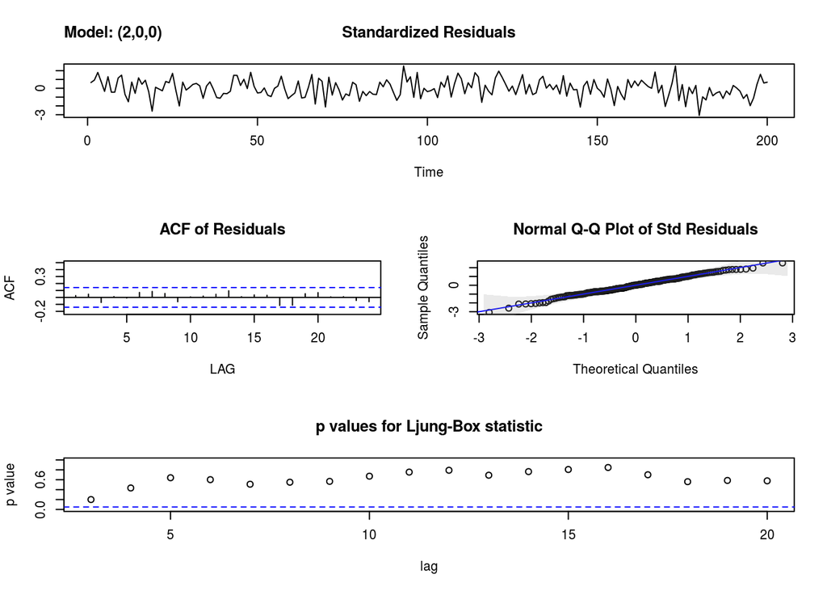

```r
x_fit$ttable
```

```
##       Estimate     SE  t.value p.value
## ar1     1.5314 0.0423  36.1606       0
## ar2    -0.8044 0.0423 -19.0163       0
## xmean  50.1456 0.2238 224.0961       0
```

Now do an *MA(1)*.

$X_t = W_t + (-0.7) W_{t-1}$

```r
y <- arima.sim(list(order=c(0,0,1), ma=(-0.7)), n=200)
y_fit <- sarima(y, p=0, d=0, q=1)
```

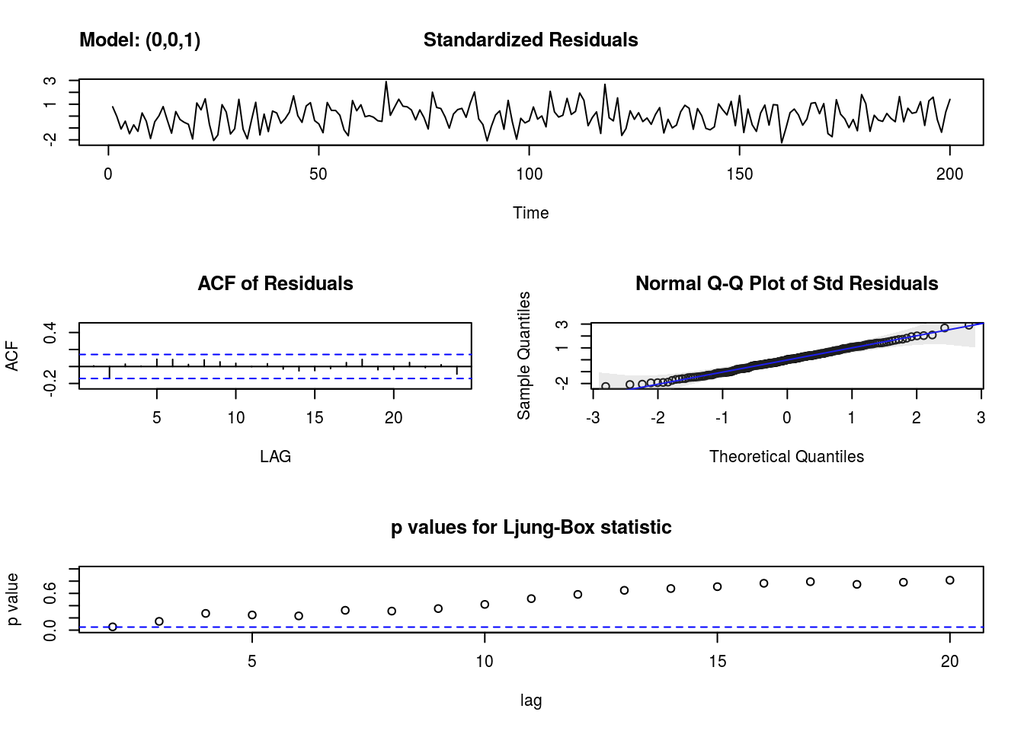

```r
y_fit$ttable
```

```
##       Estimate     SE  t.value p.value
## ma1    -0.7962 0.0387 -20.5550  0.0000
## xmean  -0.0047 0.0143  -0.3256  0.7451
```

### YAE

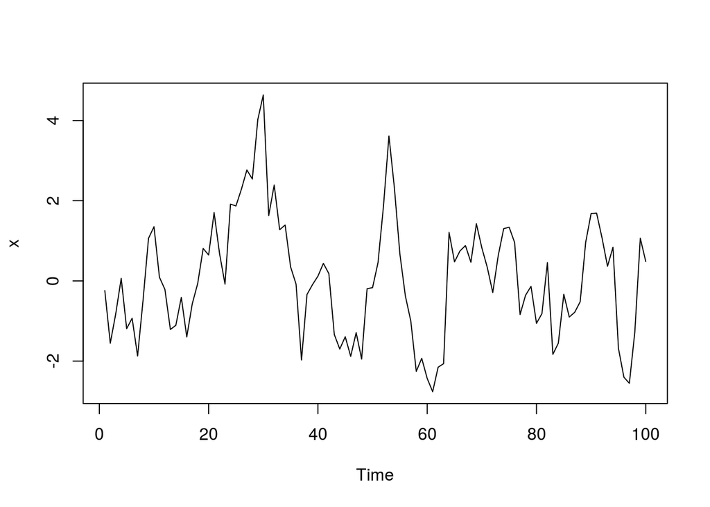

```r
x <- arima.sim(model = list(order = c(1, 0, 0), ar = .9), n = 100)

plot(x)
```

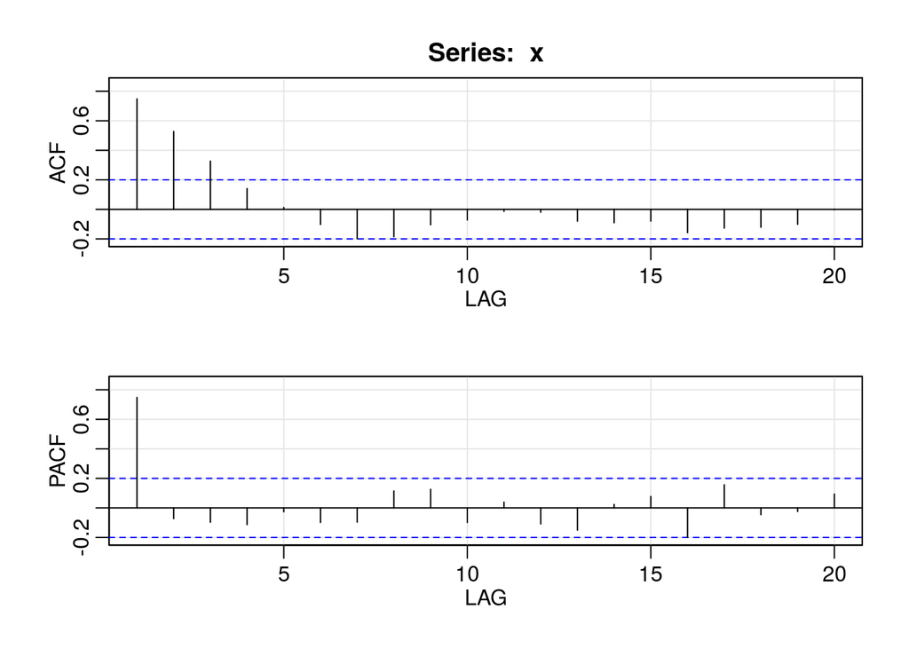

```
##         ACF  PACF
##  [1,]  0.75  0.75
##  [2,]  0.53 -0.07
##  [3,]  0.33 -0.10
##  [4,]  0.14 -0.11
##  [5,]  0.01 -0.03
##  [6,] -0.10 -0.10
##  [7,] -0.20 -0.10
##  [8,] -0.19  0.11
##  [9,] -0.10  0.13
## [10,] -0.07 -0.10
## [11,] -0.01  0.04
## [12,] -0.02 -0.11
## [13,] -0.08 -0.15
## [14,] -0.09  0.02
## [15,] -0.08  0.08
## [16,] -0.16 -0.20
## [17,] -0.13  0.16
## [18,] -0.12 -0.05
## [19,] -0.10 -0.02
## [20,]  0.00  0.09
```

```r
acf2(x)
```

```r
x_fit <- sarima(x, p=1, d=0, q=0)
```

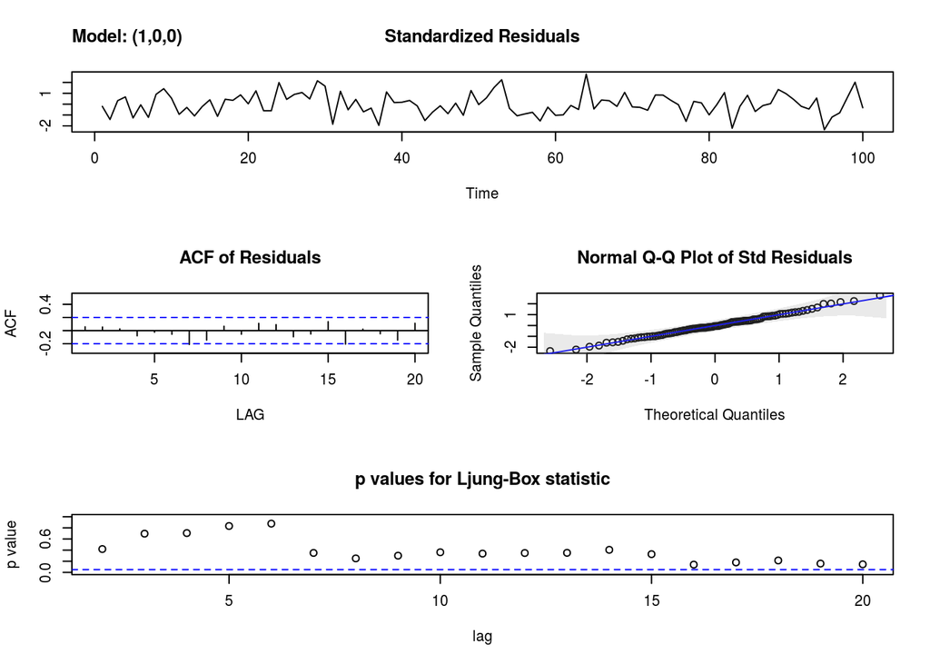

```r
x_fit$ttable
```

```
##       Estimate     SE t.value p.value
## ar1     0.7418 0.0652 11.3753  0.0000
## xmean   0.0587 0.3711  0.1581  0.8747
```

### AR and MA together

This is the *awesome* **ARMA** model.

$X_t = \phi X_{t-1} + W_t + \theta W_{t-1}$

Where $\phi X_{t-1}$ comes from the AR model $X_t = \phi X+{t-1} + W_t + \epsilon_t$ and $\epsilon_t$ is replaced with MA model results $\theta W_{t=1}$.

As noted above, the **ACF** and **PACF** both will trail off when the model is **ARMA**.

This is “*natural*” for ts because ts are *typically* corrolated.

Such a model can be generated with *order=c(1, 0, 1)*

Here’s an example **ARMA(1, 1)**

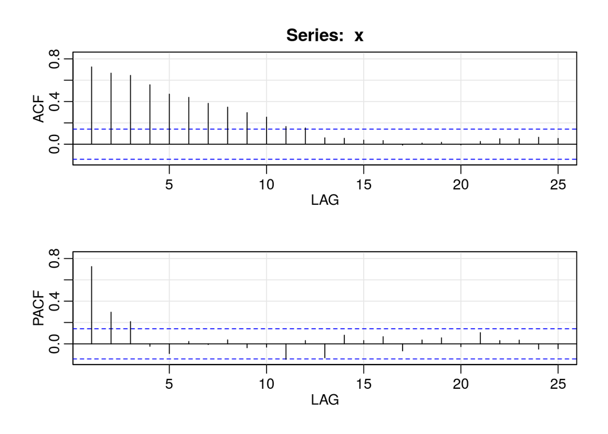

```
##         ACF  PACF
##  [1,]  0.72  0.72
##  [2,]  0.67  0.30
##  [3,]  0.65  0.21
##  [4,]  0.56 -0.02
##  [5,]  0.47 -0.09
##  [6,]  0.44  0.02
##  [7,]  0.38 -0.01
##  [8,]  0.35  0.04
##  [9,]  0.30 -0.04
## [10,]  0.25 -0.03
## [11,]  0.17 -0.15
## [12,]  0.15  0.03
## [13,]  0.06 -0.13
## [14,]  0.06  0.08
## [15,]  0.04  0.03
## [16,]  0.03  0.07
## [17,] -0.01 -0.07
## [18,]  0.01  0.04
## [19,]  0.02  0.06
## [20,] -0.01 -0.03
## [21,]  0.03  0.11
## [22,]  0.05  0.03
## [23,]  0.05  0.04
## [24,]  0.07 -0.05
## [25,]  0.05 -0.05
```

```r
x <- arima.sim(list(order=c(1, 0, 1), ar=.9, ma=(-0.4)), n=200)
acf2(x)
```

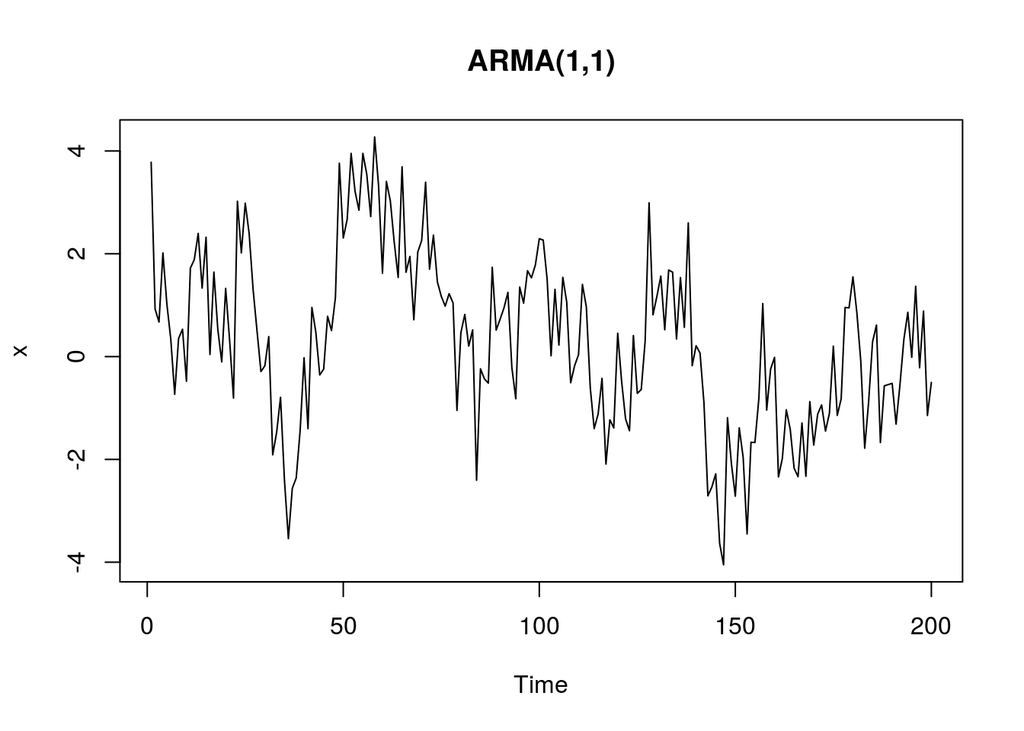

```r
plot(x, main='ARMA(1,1)')
```

### Esimating

It’s not possible to determine the order of the model. The best thing to do is small, i.e. **ARMA(1,1)** and move up from there.

`sarima()` can be used to estimate the model as with **MA** and **AR** models.

### Model Choice

2 best choices are **AIC** and **BIC**.

In general, the more parameters added to a model the lower the error gets, regardless of whether the parameters add to the model or not. **AIC** and **BIC** address this by adding a penalty for more parameters. **AIC** uses k=2 vs **BIC** k=log(n) but both typically agree. Lower values are better.

So, fit multiple models, check the **AIC** and **BIC** and then pick the model that supports your hypothesis (Sorry, no conservatives allowed) pick the model with the lowest **I**nformation **C**riterion values.

Here’s an example calculating the *growth rate* of the GNP. (*growth rate* can be calcuated by differencing the log of the data)

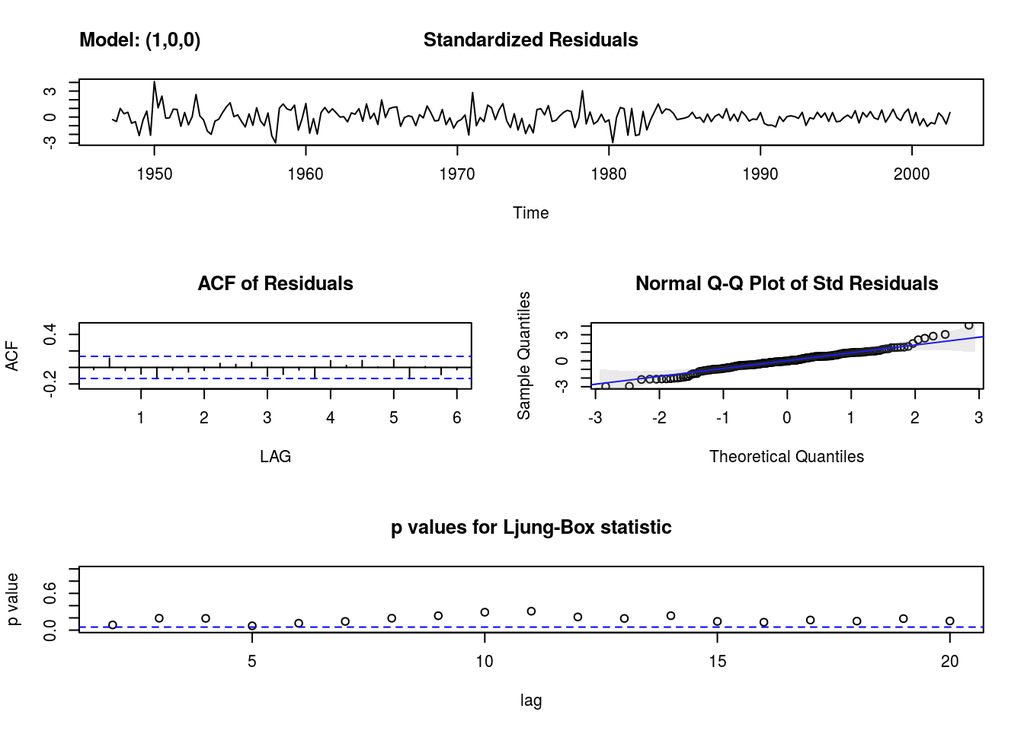

```
## $fit
##
## Call:
## stats::arima(x = xdata, order = c(p, d, q), seasonal = list(order = c(P, D,
##     Q), period = S), xreg = xmean, include.mean = FALSE, optim.control = list(trace = trc,
##     REPORT = 1, reltol = tol))
##
## Coefficients:
##          ar1   xmean
##       0.3467  0.0083
## s.e.  0.0627  0.0010
##
## sigma^2 estimated as 9.03e-05:  log likelihood = 718.61,  aic = -1431.22
##
## $degrees_of_freedom
## [1] 220
##
## $ttable
##       Estimate     SE t.value p.value
## ar1     0.3467 0.0627  5.5255       0
## xmean   0.0083 0.0010  8.5398       0
##
## $AIC
## [1] -8.294403
##
## $AICc
## [1] -8.284898
##
## $BIC
## [1] -9.263748
```

```r
gnpgr <- diff(log(gnp))

sarima(gnpgr, 1, 0, 0)
```

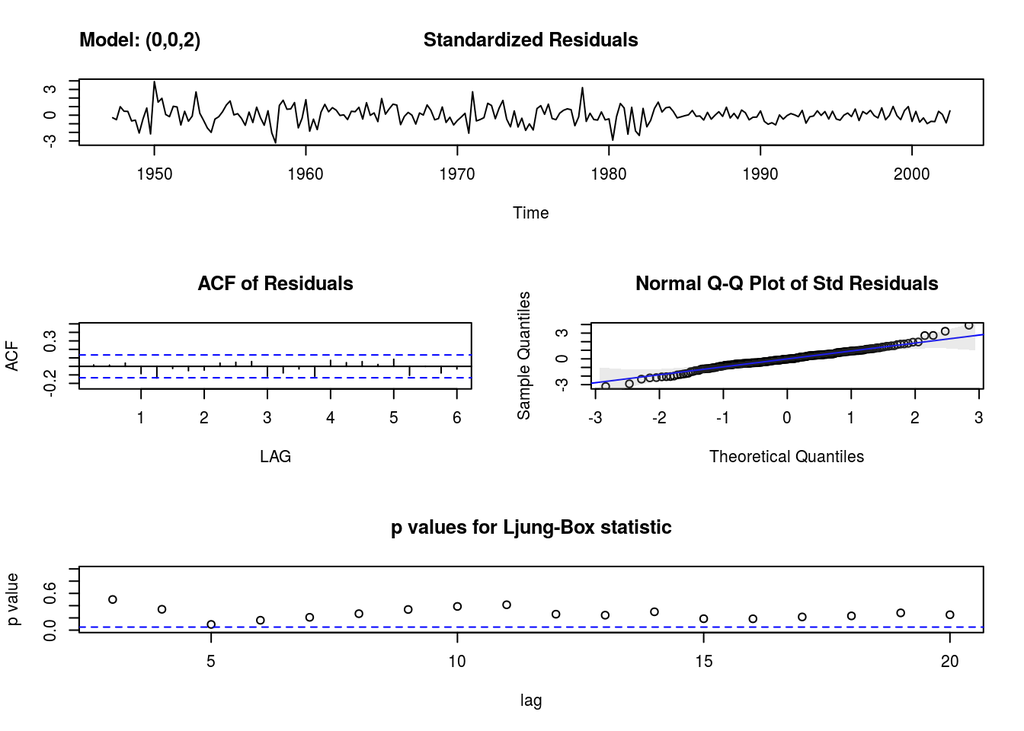

```
## $fit
##
## Call:
## stats::arima(x = xdata, order = c(p, d, q), seasonal = list(order = c(P, D,
##     Q), period = S), xreg = xmean, include.mean = FALSE, optim.control = list(trace = trc,
##     REPORT = 1, reltol = tol))
##
## Coefficients:
##          ma1     ma2   xmean
##       0.3028  0.2035  0.0083
## s.e.  0.0654  0.0644  0.0010
##
## sigma^2 estimated as 8.919e-05:  log likelihood = 719.96,  aic = -1431.93
##
## $degrees_of_freedom
## [1] 219
##
## $ttable
##       Estimate     SE t.value p.value
## ma1     0.3028 0.0654  4.6272  0.0000
## ma2     0.2035 0.0644  3.1594  0.0018
## xmean   0.0083 0.0010  8.7178  0.0000
##
## $AIC
## [1] -8.297695
##
## $AICc
## [1] -8.287855
##
## $BIC
## [1] -9.251712
```

```r
sarima(gnpgr, 0, 0, 2)
```

For the first model we get

> $AIC [1] -8.294403

> $AICc [1] -8.284898

> $BIC [1] -9.263748

and for the second

> $AIC [1] -8.297695

> $AICc [1] -8.287855

> $BIC [1] -9.251712

The **BIC** preferred the **AR(1)** model and the **AIC** prefered the **MA(2)**. Since the **AR(1)** is the simpler model, this would be the preferred model to choose. **Alway go for the simpler model if the IC’s don’t agree but are close**

## Residual Analysis

We want to makes sure the residuals are *white gausian noise*. The `sarima()` function reutrns 4 plots:

- *Standardized residuals* - look for patterns, if so, go back to mdoel
- *Sample ACF of resisduals* - Look that at least 95% of values fall between the “blue lines”
- *Q-Q plot* - Thies checks for “normality” of the residuals (The *Gausian* part). There are usually departures from the line at the ends, as long as they are not extreme, it’s OK.
- *Q-statistic p-values* - As long as most of the points are above the blue line, it’s OK, otherwise go back to the model.

### Example

```r
dl_varve <- diff(log(varve))

m1 <- sarima(dl_varve, 0, 0, 1)
```

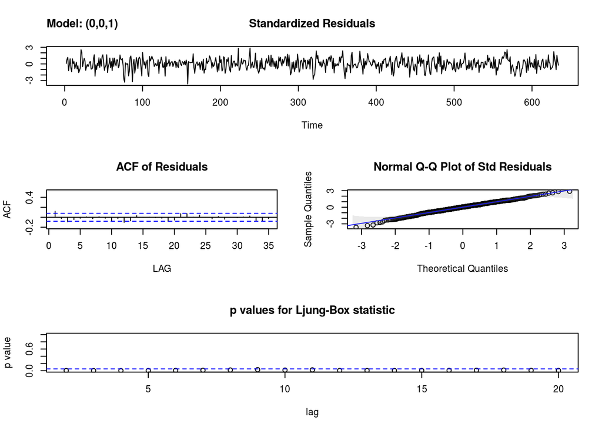

```r
m2 <- sarima(dl_varve, 0, 0, 2)
```

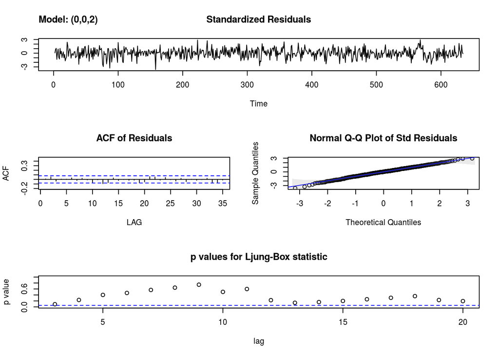

```r
m3 <- sarima(dl_varve, 1, 0, 1)
```

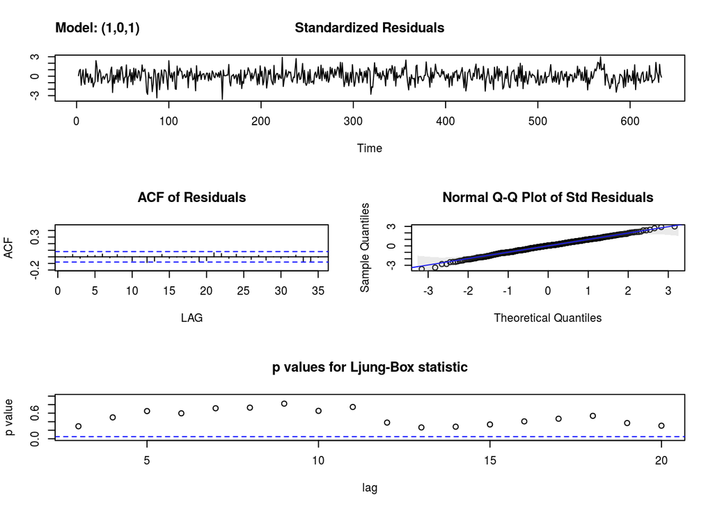

```r
m1$AIC
```

```
## [1] -0.4406366
```

```r
m1$BIC
```

```
## [1] -1.426575
```

```r
m2$AIC
```

```
## [1] -0.4629629
```

```r
m2$BIC
```

```
## [1] -1.441871
```

```r
m3$AIC
```

```
## [1] -0.467376
```

```r
m3$BIC
```

```
## [1] -1.446284
```

> AIC and BIC help you find the model with the smallest error using the least number of parameters. The idea is based on the *parsimony principle*, which is basic to all science and tells you to choose the simplest scientific explanation that fits the evidence.

### Reitterating what to look for in residuals charts

1. The standardized residuals should behave as a white noise sequence with mean zero and variance one. Examime the residual plot for departures from this behavior.
2. The sample ACF of the residuals should look like that of white noise. Examine the ACF for departures from this behavior.
3. Normality is an essential assumption when fitting ARMA models. Examine the Q-Q plot for departures from normality and to identify outliers.
4. Use the Q-statistic plot to help test for departures from whiteness of the residuals.

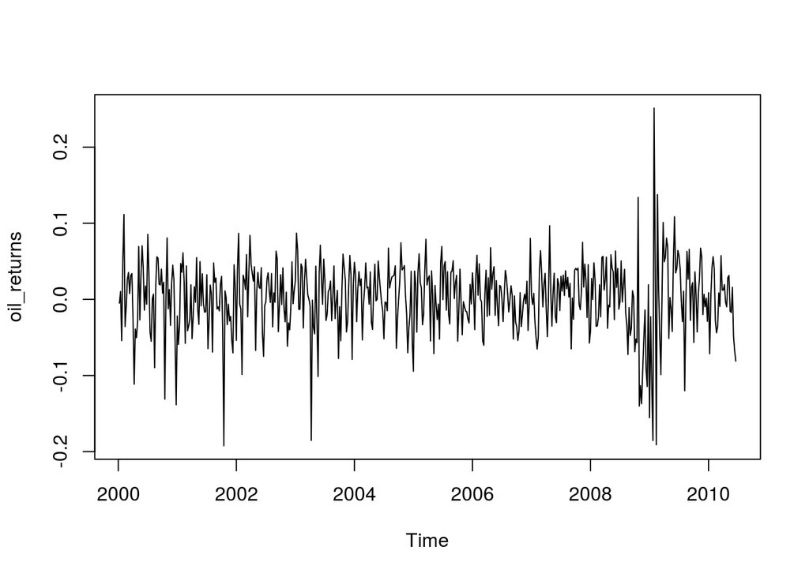

```r
oil_returns = diff(log(oil))
plot(oil_returns)
```

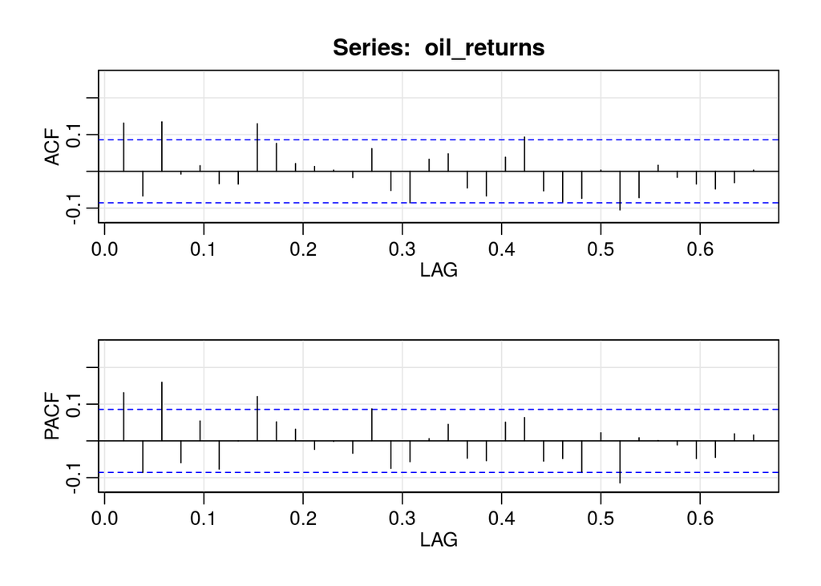

```
##         ACF  PACF
##  [1,]  0.13  0.13
##  [2,] -0.07 -0.09
##  [3,]  0.13  0.16
##  [4,] -0.01 -0.06
##  [5,]  0.02  0.05
##  [6,] -0.03 -0.08
##  [7,] -0.03  0.00
##  [8,]  0.13  0.12
##  [9,]  0.08  0.05
## [10,]  0.02  0.03
## [11,]  0.01 -0.02
## [12,]  0.00  0.00
## [13,] -0.02 -0.03
## [14,]  0.06  0.09
```

[output cut: 20 more lines]

```r
acf2(oil_returns)
```

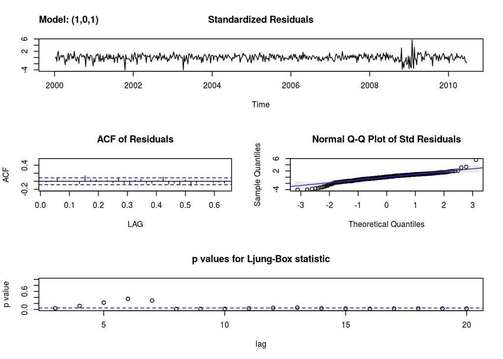

```
## $fit
##
## Call:
## stats::arima(x = xdata, order = c(p, d, q), seasonal = list(order = c(P, D,
##     Q), period = S), xreg = xmean, include.mean = FALSE, optim.control = list(trace = trc,
##     REPORT = 1, reltol = tol))
##
## Coefficients:
##           ar1     ma1   xmean
##       -0.5264  0.7146  0.0018
## s.e.   0.0871  0.0683  0.0022
##
## sigma^2 estimated as 0.002102:  log likelihood = 904.89,  aic = -1801.79
##
## $degrees_of_freedom
## [1] 541
##
## $ttable
##       Estimate     SE t.value p.value
## ar1    -0.5264 0.0871 -6.0422  0.0000
## ma1     0.7146 0.0683 10.4699  0.0000
## xmean   0.0018 0.0022  0.7981  0.4252
##
## $AIC
## [1] -5.153838
##
## $AICc
## [1] -5.150025
##
## $BIC
## [1] -6.130131
```

```r
sarima(oil_returns, 1, 0, 1)
```